# Tips and Tricks

The jupyter notebook allows code and markdown. For example:

# Heading Level 1

## Heading Level 2

### Heading Level 3

##### Heading Level 4

Regular text. Bla bla bla bla bla

math: $f(x) = {x^2}$

Bullet points:

- first item
- second item

## There are two modes for cells: edit and select

- edit shows green frame and let's you change the contents of a cell
- select shows gray frame let's you use keyboard short cuts, such as c, v, x, dd, a, b (copy, paste, cut, delete, new cell above, new cell below)

## To know which directory you're in you can use *pwd*

```python
pwd
```

```
'/home/wendell/code/learnpython'
```

## To get help about functions use "*shift + tab*"

```
linspace()
```

# Recap and useful manipulations

```python
%pylab inline
```

We learned about different types of variables

```python
x = 1
type(x)
```

```
int
```

```python
x = 1.
type(x)
```

```
float
```

```python
x = "Hello"
type(x)
```

```
str
```

```python
x = False
type(x)
```

```
bool
```

## boolean operations

### input: 2 booleans, returns: 1 boolean

- and
- or

### input: 2 numbers, returns: 1 boolean

- is equal to ==
- not equal to !=
- greater/smaller than >/<
- greater or equal >=

```python
2 >= 2
```

```
True
```

```python
True > False
```

```
True
```

```python
1 > 2/2
```

```
False
```

```python
x = []
type(x)
```

```
list
```

```python
len([2,3,4])
```

```
3
```

```python
x = array([1,2,3])
type(x)
```

```
numpy.ndarray
```

```python
x = array([[1,2,3],[4,5,6]])
```

```python
print(x)
```

```
[[1 2 3]
 [4 5 6]]
```

```python
x.shape
```

```
(2, 3)
```

```python
y = np.full((2,3),0)
print(y)
```

```
[[ 0.  0.  0.]
 [ 0.  0.  0.]]
```

What are the types of the following variables x?

- x = [1, 2, 3],
- x = [1., 2., 3.],
- x = ["Hello", "World"]
- x = ["Hello", 1, 5.4]

What are the types of x[1] ?

- x = [1, 2, 3],
- x = [1., 2., 3.],
- x = ["Hello", "World"]
- x = ["Hello", 1, 5.4]

Consider

- x = [1, 2, 3]
- y = array([1,2,3])

What is going on when you try to run the following?

- x + 1
- y + 1

Conclusions:

- lists are of type list even if they carry elements of different types
- Because list can carry different types [1,2,3] + 1 is not defined
- for operations on a bunch of numbers use **array**

```python
#
```

# ways to use "+"

try to run the following line:

```python
[1,2,3] + 1
```

```
---------------------------------------------------------------------------
TypeError                                 Traceback (most recent call last)
<ipython-input-18-0f7f56b3e161> in <module>()
----> 1 [1,2,3] + 1

TypeError: can only concatenate list (not "int") to list
```

error message implies:

```
[1,2,3] + []
```

works. Talk to your neighbor and find out how "+" works with lists.

```python
[1,2,3] + ["Hello"]
```

```
[1, 2, 3, 'Hello']
```

You can use "+" on strings

```python
"Hello" + " " + "World" + "!"
```

```
'Hello World!'
```

You can think of a string as a list of characters. The variable type is string, not list though!

# Indexing/Slicing

## slicing with ":"

```python
x = [0,1,2,3,4,5,6,7]
```

```python
x[:]
```

```
[0, 1, 2, 3, 4, 5, 6, 7]
```

```python
x[-1]
```

```
7
```

```python
print(x[0:3])
print(x[3])
```

```
[0, 1, 2]
3
```

Last index is not displayed!

```python
x[2:]
```

```
[2, 3, 4, 5, 6, 7]
```

```python
print(x[:-2])
print(x[0::3])
```

```
[0, 1, 2, 3, 4, 5]
[0, 3, 6]
```

Indexing works on strings too!

```python
x = "HelloWorld"
```

```python
x[3:6]
```

```
'loW'
```

## slicing arrays by using list of indices

```python
x = [10,3,4,2,888,99,1000,3]
```

```python
y = array(x)
```

```python
ind = [0,3,4,5,7]
```

```python
y[ind]
```

```
array([ 10,   2, 888,  99,   3])
```

## slicing arrays by using array of booleans

```python
indbool = array([True,False,False,True,True,True,False,True])
```

```python
y[indbool]
```

```
array([ 10,   2, 888,  99,   3])
```

Why would that ever be useful?

```python
y < 100
```

```
array([ True,  True,  True,  True, False,  True, False,  True], dtype=bool)
```

```python
print(y)
print(y < 100 )
```

```
[  10    3    4    2  888   99 1000    3]
[ True  True  True  True False  True False  True]
```

I want to give a challenge that uses smart slicing. Before I just want to make sure everyone understands plotting.

```
(0, 4)
```

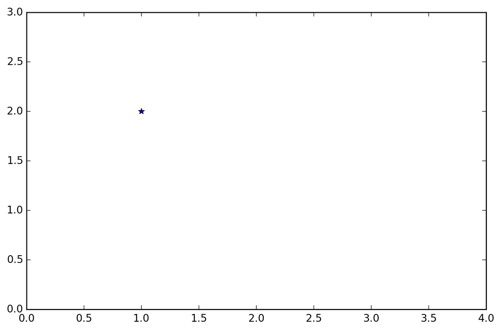

```python
plot([1],[2],"*")
ylim((0,3))
xlim((0,4))
```

```
(0, 4)
```

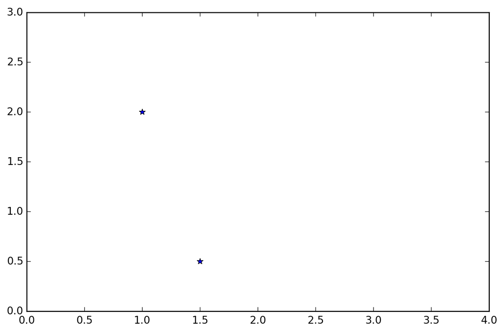

```python
plot([1, 1.5],[2, 0.5],"*")
ylim((0,3))
xlim((0,4))
```

## smart slicing challenge

Discuss with a partner and explain the output of the following three lines of code:

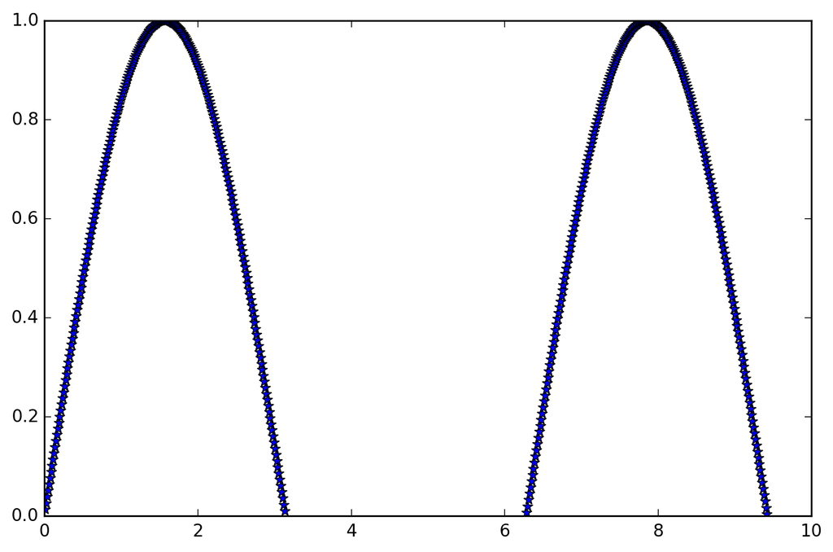

```python
x = linspace(0,4*pi,num=1000)
y = sin(x)
plot(x[y>0],y[y>0],'*')
```

# "if" statements

```python
x = 2
y = 1
if x < y:
    print("x is smaller than y")
else:
    print("x is equal to or larger than y")
```

```
x is equal to or larger than y
```

```python
x = 1
y = 2
if x < y:
    print("x is smaller than y")
elif x == y:
    print("x is equal to y")
else:
    print("x is lager than y")
```

```
x is smaller than y
```

```python
"hello" == "Hello"
```

```
False
```

```python
[1,3,2] == [1,2,3]
```

```
False
```

Advanced function challenge:

- find the definition of the Heaviside step function in its discrete form (wikipedia)
- define this function in python (name it step(x) )
- call your function with the argument x = -1, x = 0, x = 1 to check if you did everything correctly

```python
def step(x):
    "This is the heaviside step function. It returns 0 for x values below 0, 1/2 for x = 0, and 1 for x > 0."
    if x < 0:
        return 0
    elif x == 0:
        return 0.5
    else:
        return 1
```

## For loops

```python
for i in [1,2,3]:
    print(i)
```

```
1
2
3
```

```python
x = [[1,2,3],[4, 5, 6]]
y = array(x)
```

```python
for i in x:
    print(i)
```

```
[1, 2, 3]
[4, 5, 6]
```

```python
for i in y:
    print(i)
```

```
[1 2 3]
[4 5 6]
```

```python
for i in ["Hello", "World","!","It's","me","!"]:
    print(i)
```

```
Hello
World
!
It's
me
!
```

```python
for apple in ["Hello", "World","!","It's","me","!"]:
    print(apple)
```

```
Hello
World
!
It's
me
!
```

```python
wordlist = ["Hello", "World","!","It's","me","!"]

for word in wordlist:
    print(word)
```

```
Hello
World
!
It's
me
!
```

Conclusion: The place holder is abritrary!

## FizzBuzz problem

```python
for i in range(1,36):
    if i%3 == 0 and i%5 == 0:
        print("FizzBuzz")
    elif i%3 == 0:
        print("Fizz")
    elif i% 5 == 0:
        print("Buzz")
    else:
        print(i)
```

```
1
2
Fizz
4
Buzz
Fizz
7
8
Fizz
Buzz
11
Fizz
13
14
FizzBuzz
16
17
Fizz
19
Buzz
Fizz
22
23
Fizz
Buzz
26
Fizz
28
29
FizzBuzz
31
32
Fizz
34
Buzz
```

# Combining plotting and loops

```python
def unit_circle(npoints):
    "This function returns the x and y values of a circle of radius 1 with center (0,0). npoints defines how many points of the circle we sample"
    alpha = linspace(0,2*pi,npoints)
    x = cos(alpha)
    y = sin(alpha)
    return x,y
```

```python
def r_circle(r,npoints):
    "This functions returns the x and y values of a circle of radius r with the center (0,0). npoints defines how many points we sample"
    alpha = linspace(0,2*pi,npoints)
    x = r*cos(alpha)
    y = r*sin(alpha)
    return x,y
```

```
(-10, 10)
```

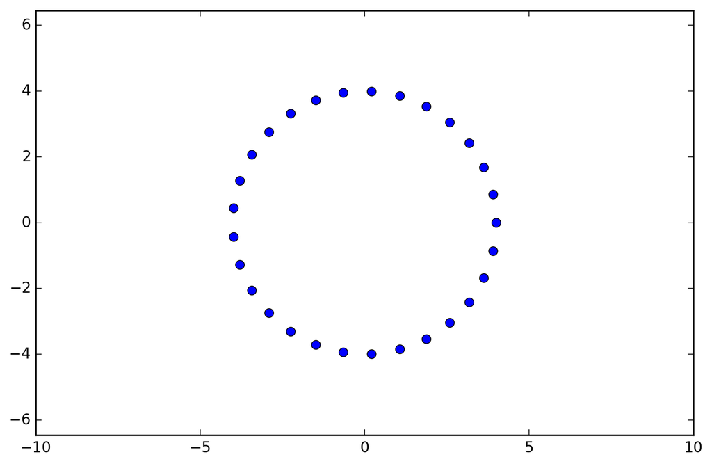

```python
#define parameters for the circle
npoints = 30
r = 4
#calculate data to plot
x = r_circle(r,npoints)[0]
y = r_circle(r,npoints)[1]

# execute the plotting
plot(x,y,"o")
axis('equal')
xlim((-10,10))
```

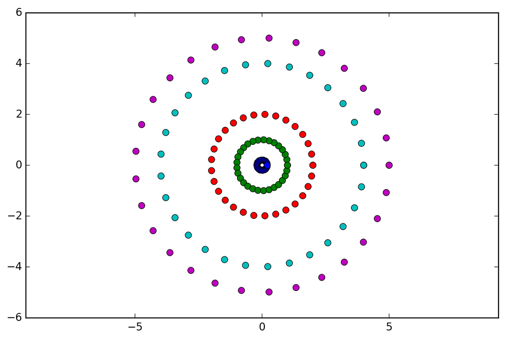

```python
npoints = 30
rlist = [0.2,1,2,4,5]
for r in rlist:

    #calculate data to plot
    x = r_circle(r,npoints)[0]
    y = r_circle(r,npoints)[1]

    # execute the plotting
    plot(x,y,"o")
    axis('equal')
    xlim((-10,10))
```